# Section 4: Hospital Pricing

Ian McCarthy | Emory University

Econ 372

# Table of contents

1. Motivation
2. What Do Hospitals Maximize?
3. Pricing and Negotiations
4. Fixed Prices
5. Two Prices
6. Current Policy Issues

class: inverse, center, middle name: motivate

# Motivation

# Now

As we know, we now spend **a lot** on health care in the U.S., and a big part of that is very high health care prices (and a big part of that is hospital prices)

# What is a hospital price?

Lots of different payers paying lots of different prices: - [Medicare fee-for-service prices](https://www.cms.gov/Outreach-and-Education/Medicare-Learning-Network-MLN/MLNProducts/Downloads/AcutePaymtSysfctsht.pdf) - [Medicaid payments](https://www.kff.org/report-section/understanding-medicaid-hospital-payments-and-the-impact-of-recent-policy-changes-issue-brief/) - Private insurance negotiations (including Medicare Advantage) - But what about the price to patients?

–

.center[ Price $\neq$ charge $\neq$ cost $\neq$ patient out-of-pocket spending]

# What is a hospital price?

Not clear what exactly is negotiated…

| .pull-left[ ### Fee-for-service - price per procedure - percentage of charges - markup over Medicare rates] |
| --- |
| .pull-right[ ### Capitation - payment per patient - pay-for-performance - shared savings] |

# Hospital prices in real life

We’ll get into the real data in a bit, but for now…a few facts:

1. Hospital services are expensive
2. Prices vary dramatically across different areas
3. Lack of competition is a major reason for high prices

class: inverse, center, middle name: objective

# What Do Hospital’s Maximize?

# Non-profit hospitals

What does it mean to be a not-for-profit hospital?

–

From an economics perspective: - Hospital assumed to maximize some objective function, $u(q,z)$, subject to a production constraint

- $q$ denotes quantity of care and $z$ denotes quality of care
- Production is constrained by the break-even condition

# Non-profit hospitals and tax benefits

- $24.6 billion in tax exemptions in 2011
- $62.4 billion in “community benefits”
- [Washington Post Article](https://www.washingtonpost.com/national/health-science/value-of-tax-breaks-for-nonprofit-hospitals-doubled-in-a-decade/2015/06/17/4162c640-1450-11e5-9ddc-e3353542100c_story.html?utm_term=.4f877a72a09f)

–

What do you think? Are these community benefits measured appropriately?

# For-profit hospitals

These are easier to study theoretically…just a standard profit maximizing firm.

- $\pi=P(q)q - C(q),$ where $q$ denotes quantity of care
- Firm has some market power and so faces a downward sloping demand curve

class: inverse, center, middle name: pricing

# Pricing and Negotiations

# Solution for NFP hospital

The hospital chooses $p_{i}$ such that

$\frac{\mathrm{d}U}{\mathrm{d}p_{i}} = U_{1} \pi_{1}^{i} + U_{2} \frac{\mathrm{d}D_{i}}{\mathrm{d}p_{i}}=0$,

where $U_{1}$ denotes the derivative of $U(\cdot)$ with respect to its first argument and similarly for $U_{2}$.

–

In general, we can’t solve this directly without knowing the hospital’s utility function.

# Example

Consider the firm’s demand curve, $d=16-q$, and cost curve, $c(q)=5+q^{2}$. Where will the firm produce and at what price? What is the firm’s markup over marginal cost?

| The profit function is, $\pi = (16-q)q - 5 - q^{2}$. Differentiating with respect to quantity yields $-q + 16 - q - 2q= 16-4q=0$, or $q=4$. At this quantity, the price is $p=12$, which is a markup of … |
| --- |
| # In-class problem (unilateral pricing) |
| Consider the firm’s demand curve, $d=40-2q$, and cost curve, $c(q)=5q+\frac{1}{2}q^{2}$. |
| 1. What is the firm’s profit maximizing choice of quantity and price? 2. What is the markup over marginal cost? |

# Negotiating with insurers

- Hospitals can’t set price on their own
- Negotiation with insurers
- Bargaining problem where insurer and hospital split some total amount
- Agent/entity with higher bargaining position will get larger share

# Nash Bargaining problem

We model this bargaining problem as a “Nash bargaining” problem. - Two people are faced with a negotiation - If they agree, each gets payoffs $u_{1}$ $u_{2}$, respectively - If they disagree, each gets some other payoff, $t_{1}$ and $t_{2}$, with $u_{1} > t_{1}$ and $u_{2} > t_{2}$ - Nash showed that the solution is $\max (u_{1}- t_{1})(u_{2} - t_{2})$

# Hospital competition

At least 2 related issues in studying hospital competitiveness: 1. How do we measure “competitiveness”? 2. What is the effect of competition?

# Defining the market

Lots of subjectivity… - Radius around a hospital? - Concentric circles to define “catchment” areas? - Patient/physician referrals? - At what product-level do hospitals compete?

# Hospital concentration over time

.pull-left[

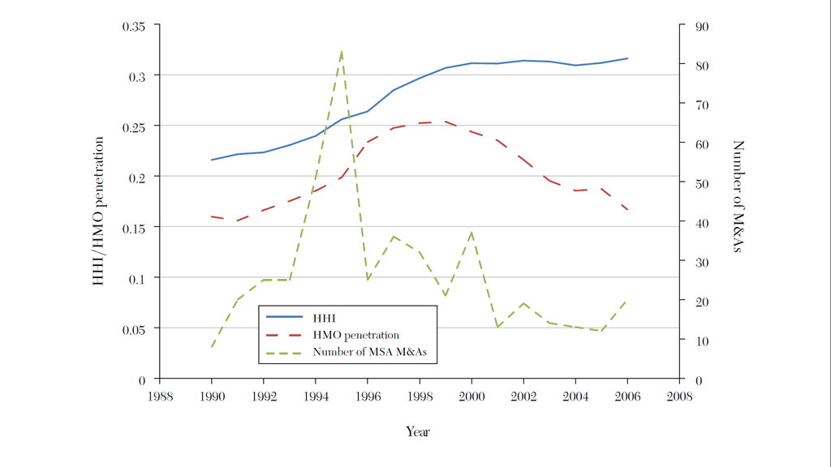

]

.pull-right[

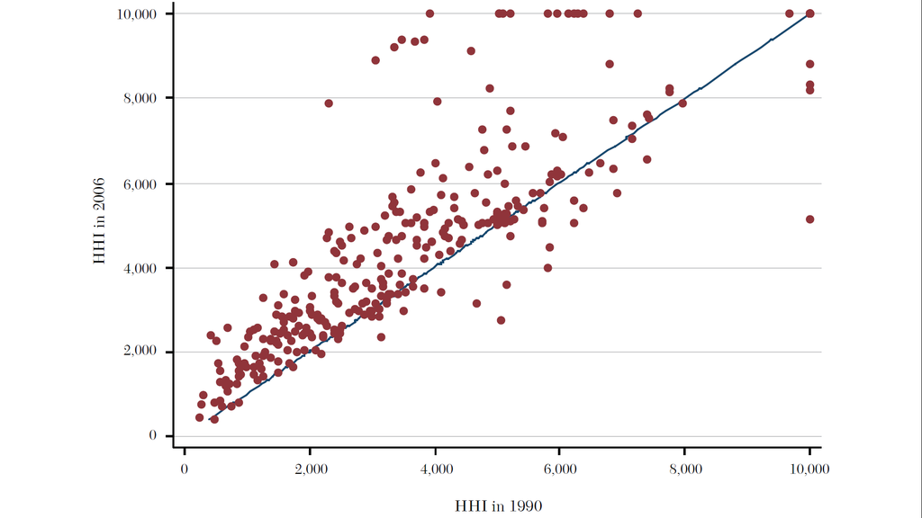

]

Source: [Gaynor, Ho, and Town (2015). The Industrial Organization of Health Care Markets. Journal of Economic Literature.](https://www.aeaweb.org/articles?id=10.1257/jel.53.2.235)

# Why?

Historical perception of hospital competition as “wasteful” and assumption that more capacity means more (unnecessary) care: - Limit public spending by limiting competition - Prevalence of certificate of need (CON) laws

class: inverse, center, middle name: public

# Fixed Prices

# Background on Medicare

- Created by the Social Security Act in 1965
- Originally health insurance to those 65 years of age and older
- Expanded to include certain disabilities (20% now below age 65)
- Consists of four parts:
  1. Part A: Hospital Insurance
  2. Part B: “Medical” Insurance (physician visits and outpatient care)
  3. Part C: Private supplemental care (Medicare plus Choice, now Medicare Advantage)
  4. Part D: Prescription Drug Coverage

# Medicare Part B

- Voluntary, but almost everyone enrolls
- Requires monthly premium ($144 in 2020)
- Small deductible and 20% co-insurance

# Medicare Part D

- Created under the Medicare Modernization Act in 2003
- Private insurance for prescription drugs
- Insurers receive payments from Medicare to enroll a given beneificiary (much like Part C)
- Many insurers offer a combined Part C+D plan

# Medicare payments

- Prospective payment system
- Begin with two “base” rates:
  - Operating base payment rates, $5,797 in 2020
  - Capital base payment rates, $462 in 2020
- Adjustments:
  - Diagnosis Related Group (higher adjustments for more complicated things)
  - Academic Medical Center
  - Disproportionate Share

# ACA and Medicaid Expansion

- Big part of ACA was Medicaid expansion
- Originally mandatory but made voluntary by Supreme Court
- Expansion covers all adults (with or without children) below age 65 and with incomes below 138% of the federal poverty line ($35,535 for family of 4 in 2020)

# Medicaid Benefits

- Pretty generous coverage
- Low to no copayments, deductibles, co-insurance
- Usually covers dental, vision, hospitals, and physician services
- Covers long term care (unlike Medicare). About 40% of all long term care is paid for by Medicaid.
- Growth in Medicaid managed care

class: inverse, center, middle name: twoprice

# Two-price Market

# Two price market and NFP

Although we don’t know the general solution for the private price, we can find how it varies with the public price…

–

$$\frac{\mathrm{d}p_{i}}{\mathrm{d}p_{j}} = - \frac{U_{11}\pi_{1}^{i}\pi_{1}^{j} + \frac{\mathrm{d}D_{i}}{\mathrm{d}p_{i}}U_{12}\pi_{1}^{j}}{\frac{\mathrm{d}^{2}U}{\mathrm{d}p_{i}^{2}}}$$

# In-class problem (two-price market)

Consider the firm’s demand curve in the private insurance market, $d=16-q$, and costs, $c(q)=5+q^{2}$. Assume that there exists a public insurer that pays a fixed price of $\bar{p}=10$.

1. How many private patients will the provider serve?
2. How many public patients?
3. What if $\bar{p}$ drops to $9.

# Cost-shifting

But how could it happen?

–

Assumes that hospitals could have increased private prices earlier but chose not too. This is technically possible if, for example: - Hospital has very low margins (maybe negative with a lower public price) - Insurer wants to prop up the hospital for competitive reasons - Hospital has diminishing returns to profits

–

but economists usually see this as a smaller effect than most policy makers.

class: inverse, center, middle name: policy

# Current Policy Issues

# Capitated Payments

There are two forms of capitated payments in Medicare now: 1. Bundled Payments 2. Accountable Care Organizations

# Section 4: Hospital Pricing

Ian McCarthy | Emory University

Econ 372

# Table of contents

1. Motivation
2. What Do Hospitals Maximize?
3. Pricing and Negotiations
4. Fixed Prices
5. Two Prices
6. Current Policy Issues

class: inverse, center, middle name: motivate

# Motivation

# Now

As we know, we now spend **a lot** on health care in the U.S., and a big part of that is very high health care prices (and a big part of that is hospital prices)

# What is a hospital price?

Lots of different payers paying lots of different prices: - [Medicare fee-for-service prices](https://www.cms.gov/Outreach-and-Education/Medicare-Learning-Network-MLN/MLNProducts/Downloads/AcutePaymtSysfctsht.pdf) - [Medicaid payments](https://www.kff.org/report-section/understanding-medicaid-hospital-payments-and-the-impact-of-recent-policy-changes-issue-brief/) - Private insurance negotiations (including Medicare Advantage) - But what about the price to patients?

–

.center[ Price $\neq$ charge $\neq$ cost $\neq$ patient out-of-pocket spending]

# What is a hospital price?

Not clear what exactly is negotiated…

| .pull-left[ ### Fee-for-service - price per procedure - percentage of charges - markup over Medicare rates] |
| --- |
| .pull-right[ ### Capitation - payment per patient - pay-for-performance - shared savings] |

# Hospital prices in real life

We’ll get into the real data in a bit, but for now…a few facts:

1. Hospital services are expensive
2. Prices vary dramatically across different areas
3. Lack of competition is a major reason for high prices

class: inverse, center, middle name: objective

# What Do Hospital’s Maximize?

# Non-profit hospitals

What does it mean to be a not-for-profit hospital?

–

From an economics perspective: - Hospital assumed to maximize some objective function, $u(q,z)$, subject to a production constraint

- $q$ denotes quantity of care and $z$ denotes quality of care
- Production is constrained by the break-even condition

# Non-profit hospitals and tax benefits

- $24.6 billion in tax exemptions in 2011
- $62.4 billion in “community benefits”
- [Washington Post Article](https://www.washingtonpost.com/national/health-science/value-of-tax-breaks-for-nonprofit-hospitals-doubled-in-a-decade/2015/06/17/4162c640-1450-11e5-9ddc-e3353542100c_story.html?utm_term=.4f877a72a09f)

–

What do you think? Are these community benefits measured appropriately?

# For-profit hospitals

These are easier to study theoretically…just a standard profit maximizing firm.

- $\pi=P(q)q - C(q),$ where $q$ denotes quantity of care
- Firm has some market power and so faces a downward sloping demand curve

class: inverse, center, middle name: pricing

# Pricing and Negotiations

# Solution for NFP hospital

The hospital chooses $p_{i}$ such that

$\frac{\mathrm{d}U}{\mathrm{d}p_{i}} = U_{1} \pi_{1}^{i} + U_{2} \frac{\mathrm{d}D_{i}}{\mathrm{d}p_{i}}=0$,

where $U_{1}$ denotes the derivative of $U(\cdot)$ with respect to its first argument and similarly for $U_{2}$.

–

In general, we can’t solve this directly without knowing the hospital’s utility function.

# Example

Consider the firm’s demand curve, $d=16-q$, and cost curve, $c(q)=5+q^{2}$. Where will the firm produce and at what price? What is the firm’s markup over marginal cost?

| The profit function is, $\pi = (16-q)q - 5 - q^{2}$. Differentiating with respect to quantity yields $-q + 16 - q - 2q= 16-4q=0$, or $q=4$. At this quantity, the price is $p=12$, which is a markup of … |
| --- |
| # In-class problem (unilateral pricing) |
| Consider the firm’s demand curve, $d=40-2q$, and cost curve, $c(q)=5q+\frac{1}{2}q^{2}$. |
| 1. What is the firm’s profit maximizing choice of quantity and price? 2. What is the markup over marginal cost? |

# Negotiating with insurers

- Hospitals can’t set price on their own
- Negotiation with insurers
- Bargaining problem where insurer and hospital split some total amount
- Agent/entity with higher bargaining position will get larger share

# Nash Bargaining problem

We model this bargaining problem as a “Nash bargaining” problem. - Two people are faced with a negotiation - If they agree, each gets payoffs $u_{1}$ $u_{2}$, respectively - If they disagree, each gets some other payoff, $t_{1}$ and $t_{2}$, with $u_{1} > t_{1}$ and $u_{2} > t_{2}$ - Nash showed that the solution is $\max (u_{1}- t_{1})(u_{2} - t_{2})$

# Hospital competition

At least 2 related issues in studying hospital competitiveness: 1. How do we measure “competitiveness”? 2. What is the effect of competition?

# Defining the market

Lots of subjectivity… - Radius around a hospital? - Concentric circles to define “catchment” areas? - Patient/physician referrals? - At what product-level do hospitals compete?

# Hospital concentration over time

.pull-left[

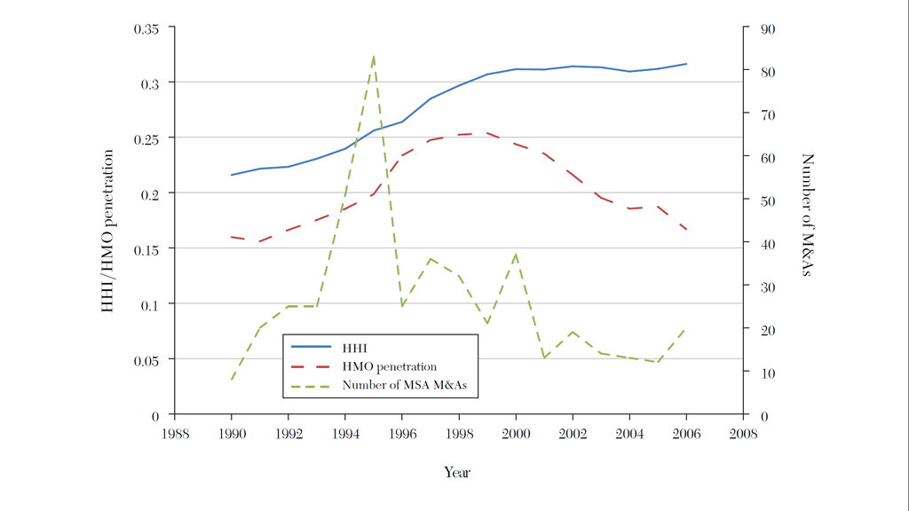

]

.pull-right[

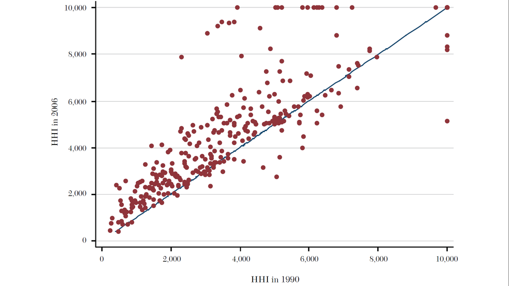

]

Source: [Gaynor, Ho, and Town (2015). The Industrial Organization of Health Care Markets. Journal of Economic Literature.](https://www.aeaweb.org/articles?id=10.1257/jel.53.2.235)

# Why?

Historical perception of hospital competition as “wasteful” and assumption that more capacity means more (unnecessary) care: - Limit public spending by limiting competition - Prevalence of certificate of need (CON) laws

class: inverse, center, middle name: public

# Fixed Prices

# Background on Medicare

- Created by the Social Security Act in 1965
- Originally health insurance to those 65 years of age and older
- Expanded to include certain disabilities (20% now below age 65)
- Consists of four parts:
  1. Part A: Hospital Insurance
  2. Part B: “Medical” Insurance (physician visits and outpatient care)
  3. Part C: Private supplemental care (Medicare plus Choice, now Medicare Advantage)
  4. Part D: Prescription Drug Coverage

# Medicare Part B

- Voluntary, but almost everyone enrolls
- Requires monthly premium ($144 in 2020)
- Small deductible and 20% co-insurance

# Medicare Part D

- Created under the Medicare Modernization Act in 2003
- Private insurance for prescription drugs
- Insurers receive payments from Medicare to enroll a given beneificiary (much like Part C)
- Many insurers offer a combined Part C+D plan

# Medicare payments

- Prospective payment system
- Begin with two “base” rates:
  - Operating base payment rates, $5,797 in 2020
  - Capital base payment rates, $462 in 2020
- Adjustments:
  - Diagnosis Related Group (higher adjustments for more complicated things)
  - Academic Medical Center
  - Disproportionate Share

# ACA and Medicaid Expansion

- Big part of ACA was Medicaid expansion
- Originally mandatory but made voluntary by Supreme Court
- Expansion covers all adults (with or without children) below age 65 and with incomes below 138% of the federal poverty line ($35,535 for family of 4 in 2020)

# Medicaid Benefits

- Pretty generous coverage
- Low to no copayments, deductibles, co-insurance
- Usually covers dental, vision, hospitals, and physician services
- Covers long term care (unlike Medicare). About 40% of all long term care is paid for by Medicaid.
- Growth in Medicaid managed care

class: inverse, center, middle name: twoprice

# Two-price Market

# Two price market and NFP

Although we don’t know the general solution for the private price, we can find how it varies with the public price…

–

$$\frac{\mathrm{d}p_{i}}{\mathrm{d}p_{j}} = - \frac{U_{11}\pi_{1}^{i}\pi_{1}^{j} + \frac{\mathrm{d}D_{i}}{\mathrm{d}p_{i}}U_{12}\pi_{1}^{j}}{\frac{\mathrm{d}^{2}U}{\mathrm{d}p_{i}^{2}}}$$

# In-class problem (two-price market)

Consider the firm’s demand curve in the private insurance market, $d=16-q$, and costs, $c(q)=5+q^{2}$. Assume that there exists a public insurer that pays a fixed price of $\bar{p}=10$.

1. How many private patients will the provider serve?
2. How many public patients?
3. What if $\bar{p}$ drops to $9.

# Cost-shifting

But how could it happen?

–

Assumes that hospitals could have increased private prices earlier but chose not too. This is technically possible if, for example: - Hospital has very low margins (maybe negative with a lower public price) - Insurer wants to prop up the hospital for competitive reasons - Hospital has diminishing returns to profits

–

but economists usually see this as a smaller effect than most policy makers.

class: inverse, center, middle name: policy

# Current Policy Issues

# Capitated Payments

There are two forms of capitated payments in Medicare now: 1. Bundled Payments 2. Accountable Care Organizations